# Regresión lineal múltiple

# 1 Modelo estadístico

El modelo de regresión lineal múltiple generaliza el modelo lineal simple por incluir $k$ variables regresoras. Se puede formular de dos formas distintas:

$$Y_i = \beta_0 + \beta_1 X_{i1} + \beta_2 X_{i2} + \cdots + \beta_{p-1}
X_{ip-1} + \varepsilon_i,\quad \varepsilon_i \sim N(0, \sigma^2)
\label{eq:modelo}$$

donde:

- $Y_i$ es la variable respuesta para la observación $i$, con $i=1,\ldots,n$.
- $\beta_j$ son los coeficientes del modelo, con $j=0,\ldots,p-1$.
- $X_{ij}$ es la $j$-ésima covariable para esa observación.
- $\varepsilon_i$ es el término de error aleatorio.
- $p$ es la cantidad de parámetros a estimar incluyendo el intercept.

## 1.1 Notación Matricial

En forma matricial, el modelo se escribe como:

$$\mathbf{Y} = \mathbf{X} \boldsymbol{\beta} + \boldsymbol{\varepsilon}$$

donde:

- $\mathbf{Y}$ es un vector $n \times 1$ de respuestas,
- $\mathbf{X}$ es una matriz $n \times p$ de diseño (incluye una columna de 1s),
- $\boldsymbol{\beta}$ es un vector $p \times 1$ de parámetros,
- $\boldsymbol{\varepsilon}$ es un vector de errores aleatorios, con $\boldsymbol{\varepsilon} \sim N(\mathbf{0}, \sigma^2 \mathbf{I})$.

Estos vectores y matrices son:

$$\begin{equation}
\begin{array}{cc}
\underset{n \times 1}{\mathbf{Y}}=\left[\begin{array}{c}
Y_1 \\
Y_2 \\
\vdots \\
Y_n
\end{array}\right] & \underset{n \times
p}{\mathbf{X}}=\left[\begin{array}{ccccc}
1 & X_{11} & X_{12} & \cdots & X_{1, p-1} \\
1 & X_{21} & X_{22} & \cdots & X_{2, p-1} \\
\vdots & \vdots & \vdots & & \vdots \\
1 & X_{n 1} & X_{n 2} & \cdots & X_{n, p-1}
\end{array}\right] \\
\underset{p \times 1}{\boldsymbol{\beta}}=\left[\begin{array}{c}
\beta_0 \\
\beta_1 \\
\vdots \\
\beta_{p-1}
\end{array}\right] & \underset{n \times
1}{\varepsilon}=\left[\begin{array}{c}
\varepsilon_1 \\
\varepsilon_2 \\
\vdots \\
\varepsilon_n
\end{array}\right]
\end{array}
\end{equation}$$

## 1.2 Observación

Notemos que, para el caso de dos variables regresoras, el modelo resulta:

$$Y_i = \beta_0 + \beta_1 X_{i1} + \beta_2 X_{i2}+\varepsilon_i,\quad con
\quad \varepsilon_i \sim N(0, \sigma^2)$$

En este caso, la esperanza condicional de $Y$ dada las variables $X_1$ y $X_2$ es

$$\begin{equation}
E(Y|X_{1},X_{2}) = \beta_0 + \beta_1 X_{1} + \beta_2 X_{2},
\label{eq:modelo2}
\end{equation}$$

A esta ecuación se la llama superficie de respuesta y su gráfico es un plano. En el caso de regresión lineal simple tenemos que $E(Y|X) = \beta_0 + \beta_1 X$ y su gráfico es una recta.

# 2 Supuestos del modelo

- $\operatorname{los} \varepsilon_i$ tienen media cero, $E\left(\varepsilon_i\right)=0$.
- $\operatorname{los} \varepsilon_i$ tienen todos la misma varianza desconocida que llamaremos $\sigma^2$ y que es el otro parámetro del modelo, $\operatorname{Var}\left(\varepsilon_i\right)=\sigma^2$.
- $\operatorname{los} \varepsilon_i$ tienen distribución normal.
- $\operatorname{los} \varepsilon_i$ son independientes entre sí, e independientes de las covariables $X_{i 1}, X_{i 2}$, $\ldots, X_{i p-1}$.

# 3 Estimación de los parámetros del modelo

## 3.1 Estimador de mínimos cuadrados

$$\hat{\boldsymbol{\beta}} = (\mathbf{X}^\top \mathbf{X})^{-1}
\mathbf{X}^\top \mathbf{y}$$

- Este estimador minimiza la suma de cuadrados de los residuos dada por

$$\min_{\boldsymbol{\beta}} \| \mathbf{y} - \mathbf{X} \boldsymbol{\beta}
\|^2$$

## 3.2 Estimador por máxima verosimilitud

De la misma manera que sucede en regresión lineal simple, se puede probar que el estimador de máxima verosimilitud para los parámetros del modelo coinciden con los de mínimos cuadrados, siempre que los errores se distribuyan en forma normal y sean independientes.

- El estimador de $\sigma^2$ es

$$\hat{\sigma}^2=\dfrac{\sum_{i=1}^n
(Y_{i}-\widehat{Y}_{i})^2}{n-p}$$
donde $p$ es la cantidad de parámetros a estimar.

# 4 Ejemplo

*Este ejemplo se obtuvo del libro Introducción al análisis de regresión lineal de Montgmoery et al. que se encuentra en las referencias.*

## 4.1 Lectura del conjunto de datos

```r
Tiempos <- read.csv("./Datos/Tiempos1.csv")
```

## 4.2 Exploración de las relaciones entre las variables

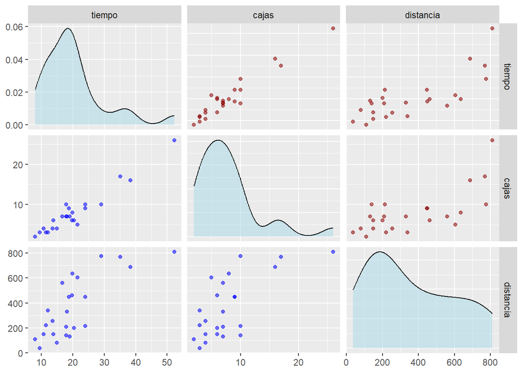

```r
library(ggplot2)
library(GGally)

ggpairs(Tiempos,
        columns = 1:3,
        mapping = aes(alpha = 0.9),
        upper = list(continuous = wrap("points", color = "darkred")),
        lower = list(continuous = wrap("points", color = "blue")),
        diag = list(continuous = wrap("densityDiag", fill = "lightblue")))
```

## 4.3 Scatter plot en 3D

```r
library(scatterplot3d)
```

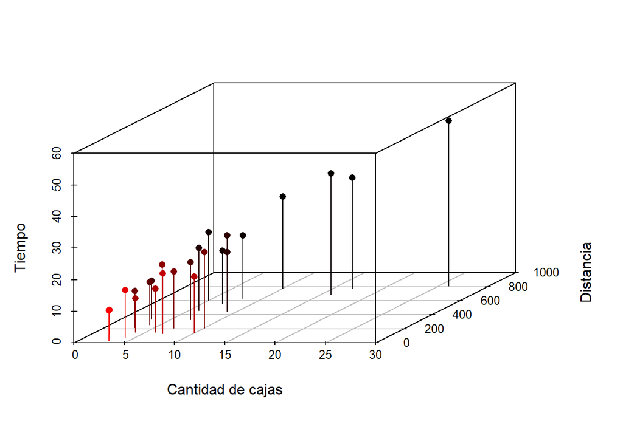

```r
scatterplot3d(x=Tiempos$cajas, y=Tiempos$distancia, z=Tiempos$tiempo, pch=16, cex.lab=1,
              highlight.3d=TRUE, type="h", xlab="Cantidad de cajas",
              ylab="Distancia", zlab="Tiempo")
```

Se puede observar que, a medida que la cantidad de cajas y la distancia aumentan, los tiempos también aumentan.

Se puede realizar un diagrama de dispersión con movimiento.

```r
library(plotly)
```

```r
plot_ly(x=Tiempos$cajas, y=Tiempos$distancia, z=Tiempos$tiempo, type="scatter3d", color=Tiempos$tiempo) %>%
  layout(scene = list(xaxis = list(title = "Cantidad"),
                      yaxis = list(title = "Distancia"),
                      zaxis = list(title = "Tiempo")))
```

[interactive chart not shown]

## 4.4 El modelo

$$Y_i=\beta_0+\beta_1 X_{1i}+\beta_2X_{2i}+\varepsilon_i,\quad con \quad
\varepsilon_i \sim N(0, \sigma^2)$$
donde

- $Y$: tiempo de atención a las máquinas expendedoras.
- $X_1$: cantidad de cajas entregadas.
- $X_2$: distancia recorrida por el representante.

### 4.4.1 El modelo en R

```r
modelo <- lm(tiempo ~ cajas + distancia, data=Tiempos)
```

### 4.4.2 La salida del modelo

```r
summary(modelo)
```

```
##
## Call:
## lm(formula = tiempo ~ cajas + distancia, data = Tiempos)
##
## Residuals:
##     Min      1Q  Median      3Q     Max
## -3.9508 -1.7810  0.0006  1.8293  4.3545
##
## Coefficients:
##             Estimate Std. Error t value Pr(>|t|)
## (Intercept) 5.137487   0.986207   5.209 3.66e-05 ***
## cajas       1.526082   0.134819  11.320 2.12e-10 ***
## distancia   0.008508   0.002955   2.879  0.00897 **
## ---
## Signif. codes:  0 '***' 0.001 '**' 0.01 '*' 0.05 '.' 0.1 ' ' 1
##
## Residual standard error: 2.516 on 21 degrees of freedom
## Multiple R-squared:  0.943,  Adjusted R-squared:  0.9376
## F-statistic: 173.7 on 2 and 21 DF,  p-value: 8.666e-14
```

### 4.4.4 El scatter plot junto con la superficie de respuesta

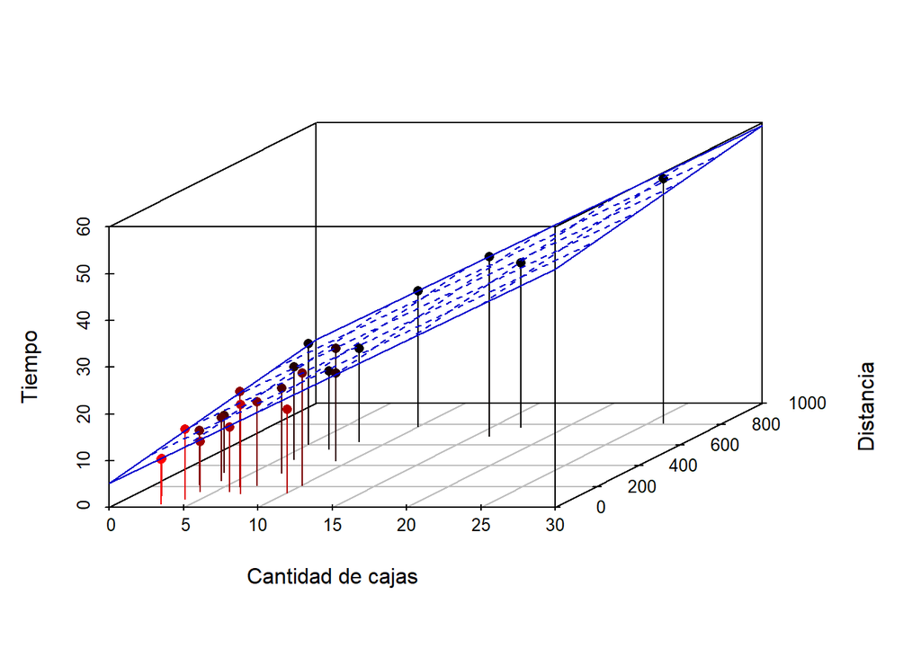

```r
# Se crea el grafico 3d y se guarda en un objeto, por ejemplo mi_3d
mi_3d <- scatterplot3d(x=Tiempos$cajas, y=Tiempos$distancia, z=Tiempos$tiempo, pch=16,            cex.lab=1,highlight.3d=TRUE, type="h", xlab="Cantidad de cajas",ylab="Distancia ", zlab="Tiempo")

# Para agregar el plano usamos $plane3d( ) con argumento modelo ajustado
mi_3d$plane3d(modelo, lty.box="solid", col="mediumblue")
```

# 5 Validación de los supuestos

## 5.1 Residuos vs. valores ajustados

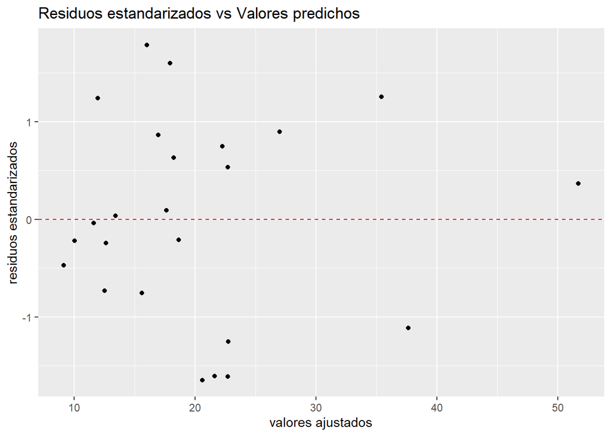

```r
ggplot(data = Tiempos, aes(x = fitted(modelo), y = rstandard(modelo))) +
  geom_point() +
  geom_hline(yintercept = 0, linetype = "dashed", color = "red") +
  labs(x = "valores ajustados", y = "residuos estandarizados",
       title = "Residuos estandarizados vs Valores predichos")
```

## 5.2 Residuos vs. cada variable regresora

Estos gráficos sirven para detectar la existencia de una relación curvilínea entre los residuos y cada variable regresora. Esto indicaría que debiera incluirse un término $X_i^2$ o $ln(X_i)$ o alguna otra transformación.

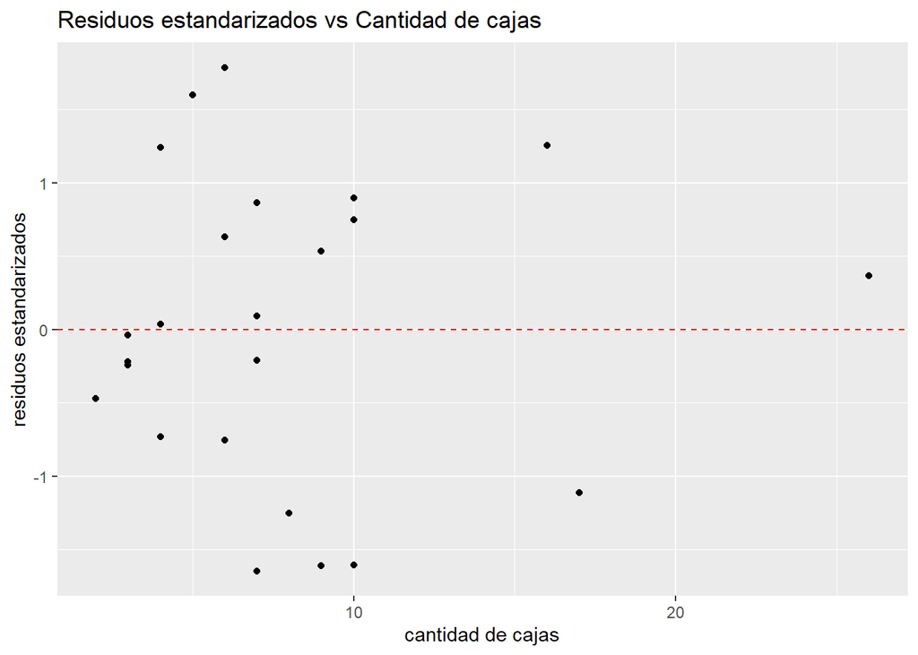

```r
ggplot(data = Tiempos, aes(x = cajas, y = rstandard(modelo))) +
  geom_point() +
  geom_hline(yintercept = 0, linetype = "dashed", color = "red") +
  labs(x = "cantidad de cajas", y = "residuos estandarizados",
       title = "Residuos estandarizados vs Cantidad de cajas")
```

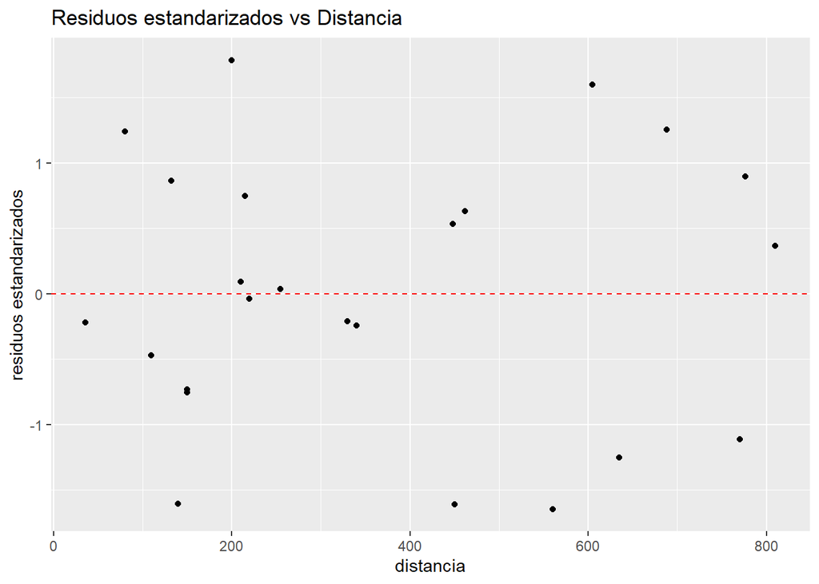

```r
ggplot(data = Tiempos, aes(x = distancia, y = rstandard(modelo))) +
  geom_point() +
  geom_hline(yintercept = 0, linetype = "dashed", color = "red") +
  labs(x = "distancia", y = "residuos estandarizados",
       title = "Residuos estandarizados vs Distancia")
```

## 5.3 Normalidad de los residuos estandarizados

- Qqnorm

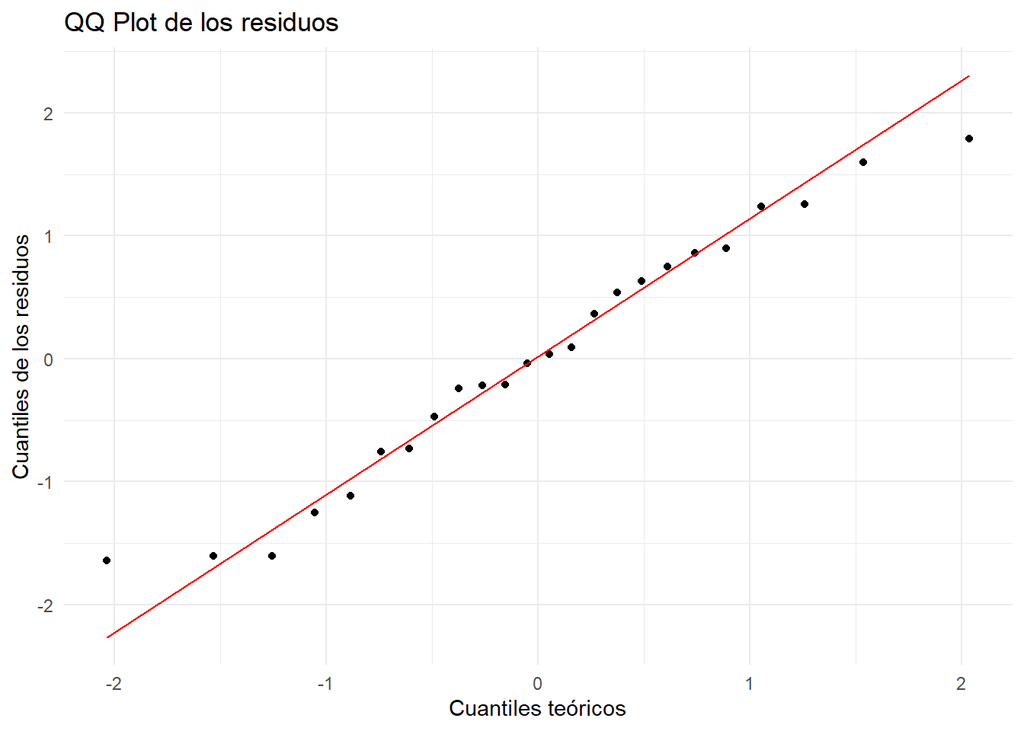

```r
residuos.df=data.frame(resid=rstandard(modelo))
ggplot(data = residuos.df, aes(sample = rstandard(modelo))) +
  stat_qq() +
  stat_qq_line(color = "red") +
  labs(title = "QQ Plot de los residuos",
       x = "Cuantiles teóricos", y = "Cuantiles de los residuos") +
  theme_minimal()
```

- Boxplot

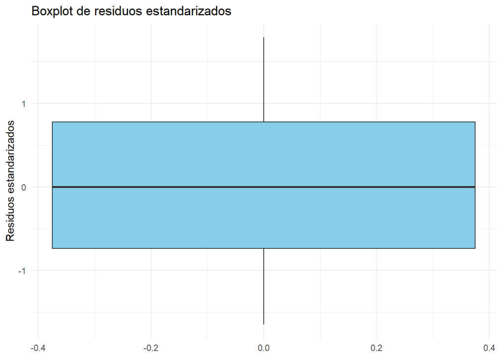

```r
ggplot(residuos.df, aes(y = rstandard(modelo))) +
  geom_boxplot(fill = "skyblue") +
  labs(title = "Boxplot de residuos estandarizados",
       y = "Residuos estandarizados") +
  theme_minimal()
```

# 6 Medidas de bondad del ajuste del modelo: $R^2$ y $R^2_{a}$

## 6.1 $R^2$

- Recordemos la definición de $R^2$, la medida que indica la proporción de variablidad explicada por el modelo.

$$R^2=1-\frac{\text { Suma de cuadrados del residuo ($SSRes$) }}{\text {
Suma total de cuadrados (SST) }}$$
- Este coeficiente tiene la misma interpretación que en regresión lineal simple.

- Pero…, hay que notar que si agregamos variables al modelo, el valor de $SSRes$ disminuye.
- Es decir, si agregamos variables al modelo, el valor de $R^2$ aumenta en forma espúrea.
- Por este motivo,cuando queremos comparar modelos de regresión que tienen distinta cantidad de variables, no conviene usar el $R^2$,
- Conviene usar otra medida que corrige ese valor teniendo en cuenta la cantidad de variables que se usaron en el modelo.

## 6.2 $R^2$ ajustado ($R^2_a$)

El $R^2_a$ penaliza por el número de variables en el modelo y solo aumenta si la nueva variable mejora realmente el modelo. Se define:

$$R_{a}^2=1-\left(\frac{\left(1-R^2\right)(n-1)}{n-k-1}\right)$$

donde:

- $n$ es el número de observaciones,
- $k$ es el número de predictores.

# 7 Test de hipótesis para los parámetros del modelo

Se puede analizar si cada parámetro es indivdualmente significativamente distinto de cero, de la misma forma que hicimos en regresión lineal simple. Los test $\textit{t}$ sirven para contrastar si cada parámetro individual $\textit{\beta_j}$ es significativamente distinto de 0. Es decir, testear las siguientes hipótesis:

$$H_0: \ \beta_j=0 \text{ vs. } \ H_1: \
\beta_j \neq 0 \ \text{ con } \ j=1,2$$
Donde:

- $\beta_1$ es el efecto de la variable $\textit{cajas}$ (que mide el número de productos entregados).
- $\beta_2$ es el efecto de la variable $\textit{distancia}$ (que mide la distancia caminada).

## 7.2 Interpretación de la salida summary(modelo):

```r
summary(modelo)
```

```
##
## Call:
## lm(formula = tiempo ~ cajas + distancia, data = Tiempos)
##
## Residuals:
##     Min      1Q  Median      3Q     Max
## -3.9508 -1.7810  0.0006  1.8293  4.3545
##
## Coefficients:
##             Estimate Std. Error t value Pr(>|t|)
## (Intercept) 5.137487   0.986207   5.209 3.66e-05 ***
## cajas       1.526082   0.134819  11.320 2.12e-10 ***
## distancia   0.008508   0.002955   2.879  0.00897 **
## ---
## Signif. codes:  0 '***' 0.001 '**' 0.01 '*' 0.05 '.' 0.1 ' ' 1
##
## Residual standard error: 2.516 on 21 degrees of freedom
## Multiple R-squared:  0.943,  Adjusted R-squared:  0.9376
## F-statistic: 173.7 on 2 and 21 DF,  p-value: 8.666e-14
```

# 8 Prueba de significancia de la regresión - Test F

Este test permite evaluar si el modelo es globalmente significativo, es decir, si al menos una de las variables regresoras explica la variabilidad de la respuesta.

- Este test se basa en el cociente de la mejora debida al modelo (SSReg) y la diferencia entre el modelo y los datos observados (SSRes).
- El objetivo es ver si al menos uno de los coeficientes $\beta_j$ de los predictores es significativamente distinto de cero.

## 8.1 Hipótesis del test F

$$H_0: \beta_1=\ldots=\beta_{p}=0 \text{
vs. } H_1: \beta_j=0 \text{ para algún } j=1,\ldots,p$$

- Si se rechaza $H_0$ implica que al menos una de las variables regresoras contribuye al modelo en forma significativa.

## 8.2 Expresión del estadístico F

- Recordemos

$$SS_T=SSReg+SSRes$$

- Entonces

$$\text{F}=\dfrac{\dfrac{\text{Variación
explicada por el modelo}}{p-1}}{\dfrac{\text{Variación
residual}}{n−p}}=\dfrac{{\dfrac{SSReg}{p-1}}}{{\dfrac{SSRes}{n-p}}}=\dfrac{MSReg}{MSRes}.$$

Donde:

## 8.3 Distribución del estadístico F.

$$\text{F}\sim F_{p-1,n-p}$$

- Regla de decisión:
  - Se rechaza $H_0$ a nivel $\alpha$ cuando $\text{F} >F_{p-1,n-p,\alpha}$, donde $F_{p-1,n-p,\alpha}$ es el valor del estadístico que deja un área de $\alpha$ a la derecha de él, cuando $H_0$ es verdadera.
- Valores grandes de F corresponde a p-valores pequeños.
- Si se rechaza $H_0$ indica que no todos los coeficientes del modelo son nulos.
- Un valor alto de $F$ indica que el modelo es significativo.

### 8.3.1 Ejemplo

```r
summary(modelo)
```

```
##
## Call:
## lm(formula = tiempo ~ cajas + distancia, data = Tiempos)
##
## Residuals:
##     Min      1Q  Median      3Q     Max
## -3.9508 -1.7810  0.0006  1.8293  4.3545
##
## Coefficients:
##             Estimate Std. Error t value Pr(>|t|)
## (Intercept) 5.137487   0.986207   5.209 3.66e-05 ***
## cajas       1.526082   0.134819  11.320 2.12e-10 ***
## distancia   0.008508   0.002955   2.879  0.00897 **
## ---
## Signif. codes:  0 '***' 0.001 '**' 0.01 '*' 0.05 '.' 0.1 ' ' 1
##
## Residual standard error: 2.516 on 21 degrees of freedom
## Multiple R-squared:  0.943,  Adjusted R-squared:  0.9376
## F-statistic: 173.7 on 2 and 21 DF,  p-value: 8.666e-14
```

- En el último renglón del summary vemos que
  - F-statistic: 173.7 on 2 and 21 DF, p-value: 8.666e-14.
- Por lo tanto el pvalor es muy chico, se rechaza $H_0$ a nivel $5\%$ indicando que, al menos algún $\beta_j$ es no nulo.
- Recordemos

$$p-\text { valor }=P\left(F_{p-1, n-p}>F_{obs}\right)$$

```r
p=3
n=nrow(Tiempos)
n
```

```
## [1] 24
```

```r
pf(173.7,p-1, n-p,lower.tail=FALSE)
```

```
## [1] 8.648615e-14
```

### 8.3.2 ¿Qué son los grados de libretad?

- al ajustar el modelo estamos usando $p$ valores (los coeficientes beta) que se determinan a partir de los datos.
- esos valores se obtienen resolviendo $p$ ecuaciones, que se conocen como las ecuaciones normales.
- estas ecuaciones surgen al minimizar el error del modelo: se derivan $p$ veces (una por cada parámetro) y se igualan a cero.
- entonces, los residuos no son completamente libres: están “condicionados” por esas $p$ ecuaciones.
- luego, si conocemos $n-p$ residuos, los otros $p$ se pueden calcular a partir de ellos.
- por eso, decimos que los residuos tienen $n-p$ grados de libertad.

En un modelo de regresión lineal múltiple, los coeficientes estimados representan el cambio esperado en la variable respuesta asociado con una unidad de cambio en cada predictor, manteniendo los demás constantes. Sin embargo, estas estimaciones son sujetas a variabilidad muestral.

Para cuantificar la precisión de estos estimadores, se calculan **intervalos de confianza (IC)**, que representan rangos plausibles donde se espera que se encuentre el valor real del parámetro con un cierto nivel de confianza (usualmente 95%).

Matemáticamente, un intervalo de confianza al 95% para un coeficiente $\beta_j$ se calcula como:

$$IC_{95\%}(\beta_j) = \hat{\beta}_j \pm t^* \cdot SE(\hat{\beta}_j)$$

Un intervalo que **incluye el cero** sugiere que no hay evidencia suficiente para afirmar que el coeficiente sea distinto de cero al nivel de confianza elegido.

```r
confint(modelo)
```

```
##                   2.5 %     97.5 %
## (Intercept) 3.086557749 7.18841554
## cajas       1.245711004 1.80645228
## distancia   0.002363293 0.01465241
```

# 9 Análisis de puntos influyentes

## 9.1 Outliers

Es importante destacar que, aunque las observaciones $(X_{i1}, X_{i2}, \dots, X_{i(p-1)}, Y_i)$ no pueden representarse gráficamente en más de dos dimensiones, siempre es posible analizar gráficamente:

- Los valores ajustados $\hat{Y}_i$
- Los residuos $r_i$

A continuación, se listan gráficos útiles para evaluar la idoneidad del modelo de regresión múltiple:

### 9.1.1 Gráfico de residuos vs. valores ajustados

- Permite evaluar:
  - La **adecuación del modelo** a los datos observados
  - La **homoscedasticidad** (detectar errores con varianza no constante)
  - La **presencia de valores extremos** (outliers)

### 9.1.2 Gráfico de residuos vs. tiempo (u orden de recolección de datos)

- Útil cuando los datos tienen un orden temporal o secuencial
- Permite detectar **correlación entre los errores** (autocorrelación)

### 9.1.3 Boxplots y gráfico de probabilidad normal de los residuos

- Sirven para evaluar si los errores:
  - Se distribuyen normalmente
  - Tienen simetría o presentan colas pesadas

### 9.1.4 Gráficos de residuos vs. cada variable predictora

- Permiten evaluar:
  - Si la relación entre la variable predictora y la respuesta es lineal
  - Si se podría requer un término cuadrático o alguna transformación
  - Si la varianza del error depende de dicha variable

### 9.1.5 Gráficos de residuos vs. variables omitidas importantes

- Ayudan a detectar efectos importantes no incluidos en el modelo
- Pueden revelar relaciones adicionales con la variable de respuesta

### 9.1.6 Gráficos de residuos vs. términos de interacción

- Evaluación visual para decidir si se necesitan **términos de interacción**
- Estos términos pueden capturar efectos combinados entre predictores

## 9.2 Leverage

Recordemos que el leverage mide qué tan lejos están las observaciones respecto del centro de los datos.

- ¿Cuándo una observación $i$ se considerará que tiene alto leverage? Cuando se cumple que

$$h_{ii}>2\bar{h}$$

- En regresión lineal simple, $\sum_{i=1}^n h_{ii}=2$. Por lo tanto, $\bar{h}=\dfrac{2}{n}.$ Entonces, una observación se considerará que tiene alto leverage si
  $$h_{ii}>\dfrac{4}{n}.$$
- En regresión lineal múltiple, $\sum_{i=1}^n h_{ii}=p$. Por lo tanto, $\bar{h}=\dfrac{p}{n}.$ Entonces, una observación se considerará que tiene alto leverage si
  $$h_{ii}>\dfrac{2 p}{n}$$
- Cabe señalar, que este criterio está ajustado por la cantidad de covariables.
- Algunos autores utilizan otro criterio sin considerar este ajuste.
  - Se considera que una observación tiene alto leverage si
    $$h_{ii}>0.5.$$
  - Se considera que una observación tiene un moderado leverage si
    $$0.2<h_{ii}<0.5.$$
- También se puede graficar un histograma de los valores $h_{ii}$ y observar si hay algún valor/es que se comporta/n encuentran lejanos al resto.

### 9.2.1 ¿Cómo detectarlos en R?

```r
hatvalues(modelo)
```

```
##          1          2          3          4          5          6          7
## 0.11992977 0.10097319 0.10024969 0.10128434 0.16642759 0.08066357 0.07620000
##          8          9         10         11         12         13         14
## 0.06254612 0.06537738 0.11367920 0.07741039 0.06437975 0.04290146 0.09998709
##         15         16         17         18         19         20         21
## 0.04661503 0.04687996 0.08033747 0.11083391 0.20438000 0.13894064 0.14675966
##         22         23         24
## 0.18537865 0.21115081 0.55671434
```

```r
p=3
which(hatvalues(modelo) > 2*p/dim(Tiempos)[1])
```

```
## 24
## 24
```

### 9.2.2 Histograma de $h_{ii}$

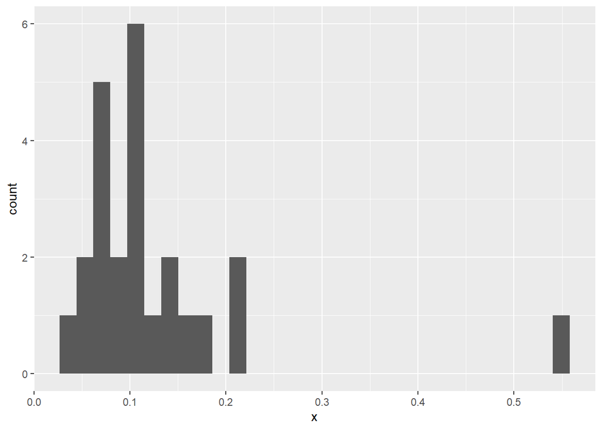

```r
leverage.df<-data.frame(x=hatvalues(modelo))

ggplot(leverage.df, aes(x=x))+
  geom_histogram()
```

## 9.3 Cook’s distance

- Mide la influencia que tiene una observación determinada en la estimación de los parámetros de la regresión.
- Una observación con distancia de Cook grande indica que la ausencia de esa observación podría cambiar los valores estimados de los parámetros.
- Es una medida que toma en cuenta tanto los residuos como los puntos de alto leverage.

$$D_i = \frac{\displaystyle{\sum_{j=1}^n}\left(\widehat{Y}_j -
\widehat{Y}_{(i)j}\right)^2}{p \widehat{\sigma}^2}$$
donde: - $p$ es la cantidad de parámetros a estimar en el modelo.

- $\widehat{Y}_{(i)j}$ corresponde al valor predicho para la j-ésima observación si se usaron las $n-1$ restantes observaciones para hacer el ajuste.
- $\widehat{Y}_{j}$ es el valor predicho para la j-ésima observación en el modelo ajustado con las $n$ observaciones.

## 9.4 Otra forma de calcular los $D_i$.

$$D_i = \dfrac{r_{si} ^2}{p} \frac{h_{ii}}{1 - h_{ii}}$$
donde $r_{si}$ es el i-ésimo residuo standarizado y $h_{ii}$ es el i-ésimo valor del leverage, ambos definidos anteriormente.

El $r_{si}$ mide cuán lejos está el valor predicho de la observación, mientras que el $h_{ii}$ mide el grado de apalancamiento de la observación $i$. Así, un valor elevado de $D_{i}$ puede deberse a un gran valor de $r_{i}$ , a un gran valor de $h_{ii}$ o a ambos.

Entonces:

- $D_i$ depende de dos factores:
  - los $r_i$ y los $h_{ii}$.
  - Cuánto más grande son los $r_i$ y los $h_{ii}$, mayor será el valor de $D_i$.
- Por lo tanto, la $j-ésima$ observación puede ser influyente si sucede alguna de las siguientes situaciones:
  - tener un $r_i$ alto y sólo un moderado valor de $h_{ii}$.
  - tener un valor alto valor de $h_{ii}$ con sólo un moderado valor de $r_i$.
  - tener tanto un alto valor de $r_i$ como un alto valor de $r_i$.

## 9.5 Criterio para determinar si una observación tiene un $D_i$ alto.

Los valores de $D_i$ se comparan con los percentiles de la distribución $F$ de Fisher con $p$ y $n-p$ grados de libertad en el numerador y denominador, respectivamente.

El criterio para decidir si una observación es influyente es el siguiente:

- Si $D_i<$ percentil 0,20 de la distribución $F_{p, n-p}$ entonces la observación no es influyente.
- Si $D_i>$ percentil 0,50 de la distribución $F_{p, n-p}$ entonces la observación es muy influyente y requerirá tomar alguna medida.
- Si $D_i$ se encuentra entre el percentil 0,20 y el percentil 0,50 de la distribución $F_{p, n-p}$ se sugiere mirar además otros estadisticos.

### 9.5.1 ¿Cómo detectarlos en R?

En el ejemplo:

```r
n=dim(Tiempos)[1]
p=3
limite05.Cook=qf(0.5,p, n-p)
limite05.Cook
```

```
## [1] 0.8148716
```

```r
limite02.Cook=qf(0.2,p, n-p)
limite02.Cook
```

```
## [1] 0.3352225
```

```r
cooks.distance(modelo)
```

```
##            1            2            3            4            5            6
## 2.221728e-03 5.753886e-02 8.259894e-03 2.793573e-02 1.716661e-01 1.664864e-02
##            7            8            9           10           11           12
## 1.469579e-02 7.105612e-02 1.964887e-04 2.393920e-02 3.662926e-05 3.045623e-05
##           13           14           15           16           17           18
## 6.607918e-04 2.174400e-03 4.678501e-03 4.241174e-02 1.163750e-02 1.125283e-01
##           19           20           21           22           23           24
## 2.184760e-01 8.405315e-02 9.061495e-02 9.429366e-02 7.143746e-02 5.606107e-02
```

Hay varias formas.

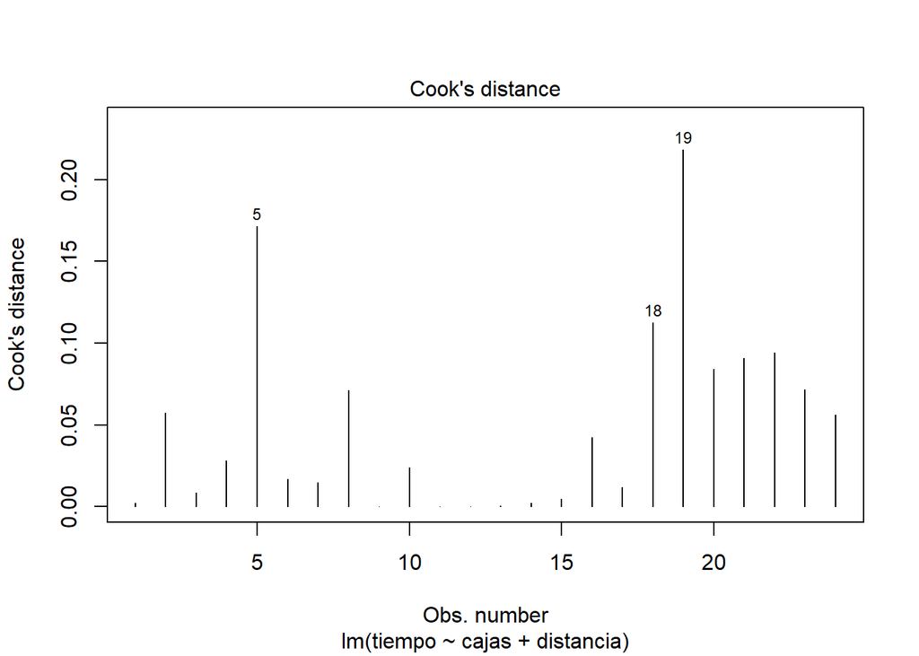

```r
# Cook's Distance
plot(modelo, which = 4)
```

```r
# Distancia de Cook
cooksd <- cooks.distance(modelo)

# Ver los índices de los puntos más influyentes
which(cooksd >limite05.Cook)
```

```
## named integer(0)
```

```r
which(limite02.Cook<cooksd)
```

```
## named integer(0)
```

# 10 Análisis de las observación influyentes

- Defino el conjunto de datos sin la observación $24$.

```r
Tiempos.sin<-Tiempos[-24,]
```

- Defino el modelo

```r
modelo.sin<-lm(tiempo ~ cajas + distancia, data=Tiempos.sin)
```

- Salida del modelo

```r
summary(modelo.sin)
```

```
##
## Call:
## lm(formula = tiempo ~ cajas + distancia, data = Tiempos.sin)
##
## Residuals:
##     Min      1Q  Median      3Q     Max
## -3.9335 -1.8143 -0.2151  2.0083  4.3673
##
## Coefficients:
##             Estimate Std. Error t value Pr(>|t|)
## (Intercept) 5.347585   1.165595   4.588 0.000178 ***
## cajas       1.480844   0.186832   7.926 1.35e-07 ***
## distancia   0.008750   0.003093   2.829 0.010364 *
## ---
## Signif. codes:  0 '***' 0.001 '**' 0.01 '*' 0.05 '.' 0.1 ' ' 1
##
## Residual standard error: 2.57 on 20 degrees of freedom
## Multiple R-squared:  0.8951, Adjusted R-squared:  0.8846
## F-statistic: 85.35 on 2 and 20 DF,  p-value: 1.61e-10
```

- Gráfico de Residuos vs. valores ajustados

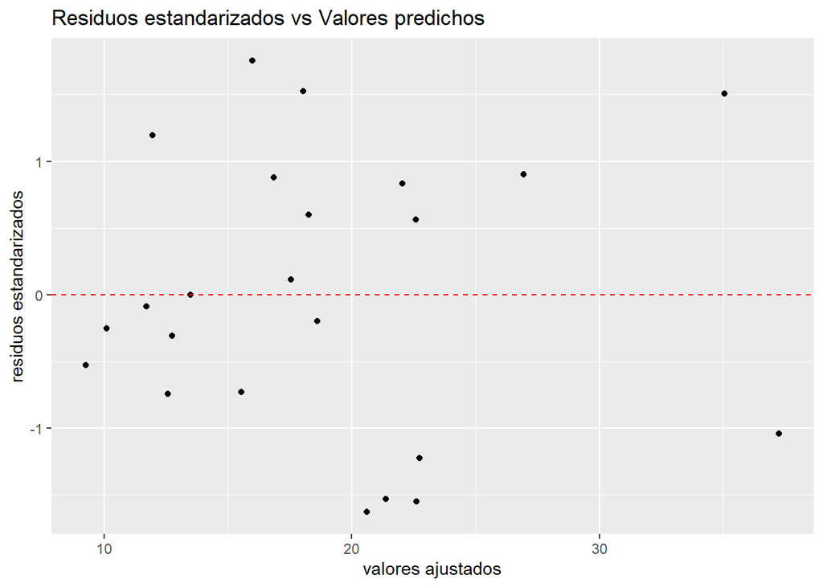

```r
ggplot(data = Tiempos.sin, aes(x = fitted(modelo.sin), y = rstandard(modelo.sin))) +
  geom_point() +
  geom_hline(yintercept = 0, linetype = "dashed", color = "red") +
  labs(x = "valores ajustados", y = "residuos estandarizados",
       title = "Residuos estandarizados vs Valores predichos")
```

- Gráfico de Residuos vs. cada variable regresora

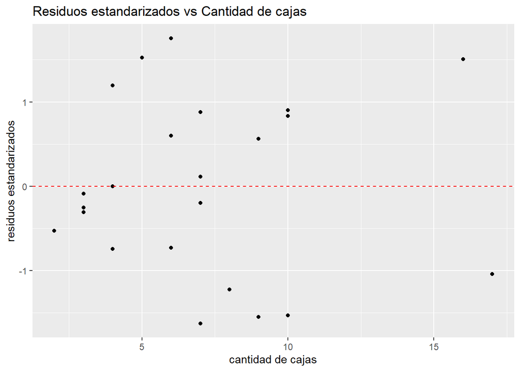

```r
ggplot(data = Tiempos.sin, aes(x = cajas, y = rstandard(modelo.sin))) +
  geom_point() +
  geom_hline(yintercept = 0, linetype = "dashed", color = "red") +
  labs(x = "cantidad de cajas", y = "residuos estandarizados",
       title = "Residuos estandarizados vs Cantidad de cajas")
```

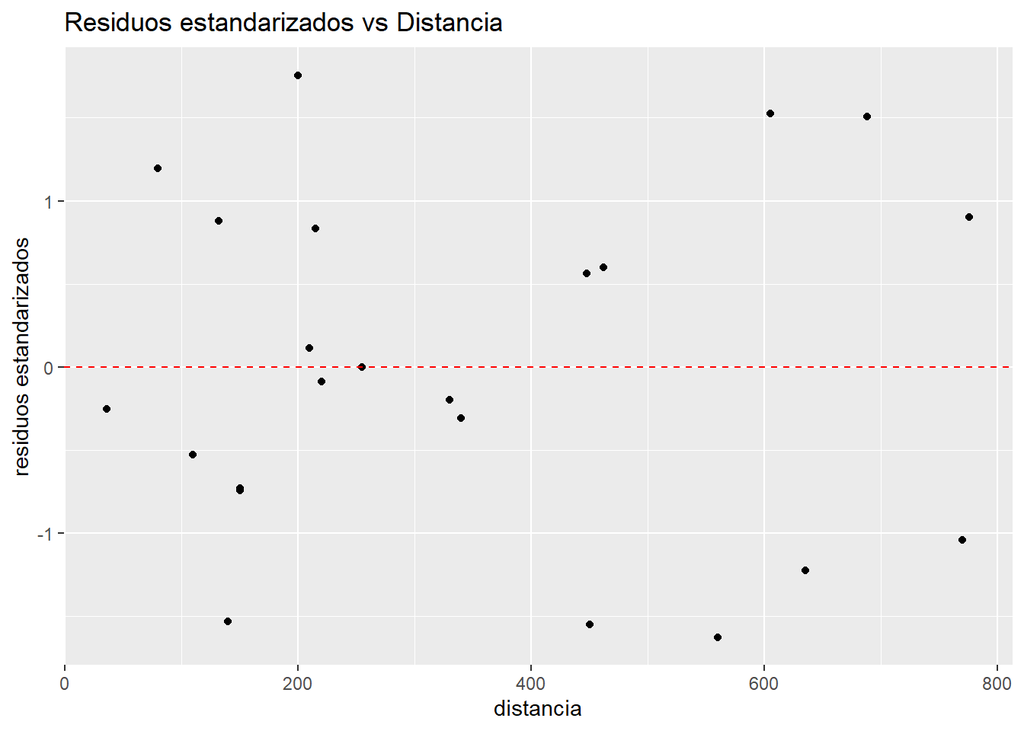

```r
ggplot(data = Tiempos.sin, aes(x = distancia, y = rstandard(modelo.sin))) +
  geom_point() +
  geom_hline(yintercept = 0, linetype = "dashed", color = "red") +
  labs(x = "distancia", y = "residuos estandarizados",
       title = "Residuos estandarizados vs Distancia")
```

- Normalidad de los residuos
  - Qqnorm

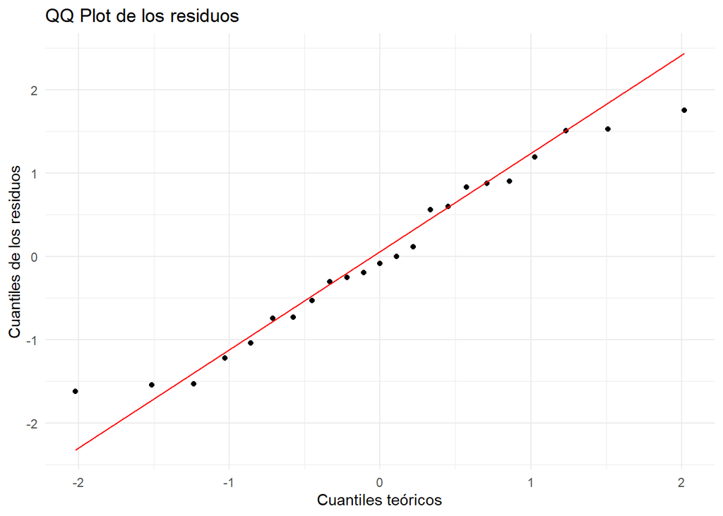

```r
residuos.sin.df=data.frame(resid=rstandard(modelo.sin))

ggplot(data = residuos.sin.df, aes(sample = rstandard(modelo.sin))) +
  stat_qq() +
  stat_qq_line(color = "red") +
  labs(title = "QQ Plot de los residuos",
       x = "Cuantiles teóricos", y = "Cuantiles de los residuos") +
  theme_minimal()
```

- Boxplot

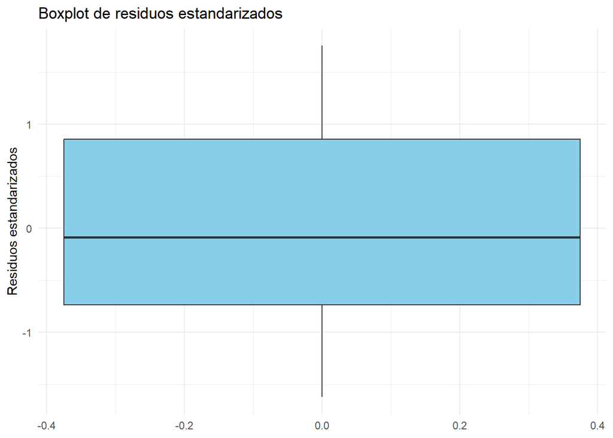

```r
ggplot(residuos.sin.df, aes(y = rstandard(modelo.sin))) +
  geom_boxplot(fill = "skyblue") +
  labs(title = "Boxplot de residuos estandarizados",
       y = "Residuos estandarizados") +
  theme_minimal()
```

### 10.0.1 Conclusión

No se detectan cambios grande en la estimación de los parámetros, la estimación de la varianza de los residuos, en las decisiones de los test individuales ni en el test global. Por lo tanto se elige el modelo con la observación $24$.

# 11 Otro ejemplo

## 11.1 Lectura del conjunto de datos

```r
Tiempos2 <- read.csv("./Datos/Tiempos.csv")
```

## 11.2 Exploración de las relaciones entre las variables

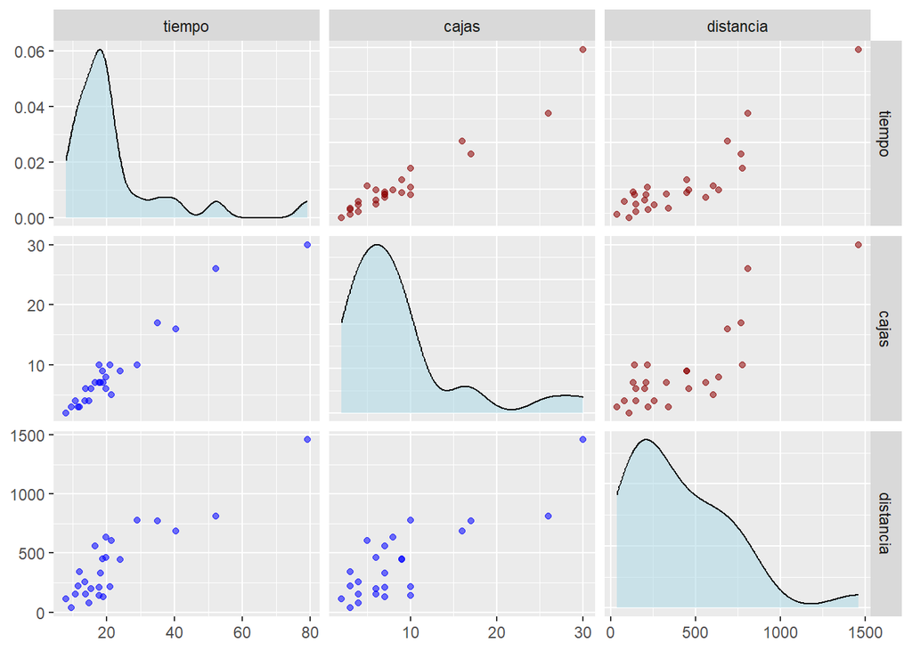

```r
library(ggplot2)
library(GGally)

ggpairs(Tiempos2,
        columns = 1:3,
        mapping = aes(alpha = 0.9),
        upper = list(continuous = wrap("points", color = "darkred")),
        lower = list(continuous = wrap("points", color = "blue")),
        diag = list(continuous = wrap("densityDiag", fill = "lightblue")))
```

## 11.3 Scatter plot en 3D

```r
library(scatterplot3d)
```

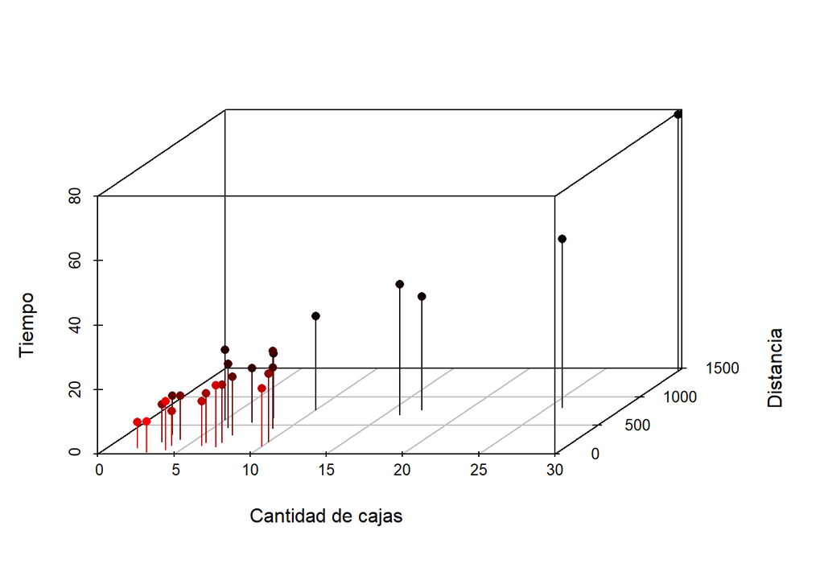

```r
scatterplot3d(x=Tiempos2$cajas, y=Tiempos2$distancia, z=Tiempos2$tiempo, pch=16, cex.lab=1,
              highlight.3d=TRUE, type="h", xlab="Cantidad de cajas",
              ylab="Distancia", zlab="Tiempo")
```

# 12 El modelo en R

```r
modelo2 <- lm(tiempo ~ cajas + distancia, data=Tiempos2)
```

## 12.1 La salida del modelo

```r
summary(modelo2)
```

```
##
## Call:
## lm(formula = tiempo ~ cajas + distancia, data = Tiempos2)
##
## Residuals:
##     Min      1Q  Median      3Q     Max
## -5.7880 -0.6629  0.4364  1.1566  7.4197
##
## Coefficients:
##             Estimate Std. Error t value Pr(>|t|)
## (Intercept) 2.341231   1.096730   2.135 0.044170 *
## cajas       1.615907   0.170735   9.464 3.25e-09 ***
## distancia   0.014385   0.003613   3.981 0.000631 ***
## ---
## Signif. codes:  0 '***' 0.001 '**' 0.01 '*' 0.05 '.' 0.1 ' ' 1
##
## Residual standard error: 3.259 on 22 degrees of freedom
## Multiple R-squared:  0.9596, Adjusted R-squared:  0.9559
## F-statistic: 261.2 on 2 and 22 DF,  p-value: 4.687e-16
```

# 13 El scatter plot junto con la superficie de respuesta

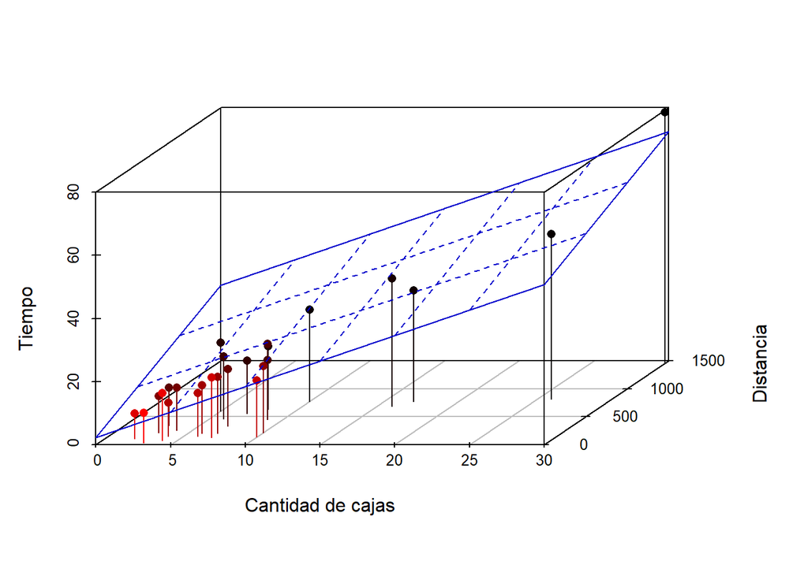

```r
# Se crea el grafico 3d y se guarda en un objeto, por ejemplo mi_3d
mi_3d <- scatterplot3d(x=Tiempos2$cajas, y=Tiempos2$distancia, z=Tiempos2$tiempo, pch=16,            cex.lab=1,highlight.3d=TRUE, type="h", xlab="Cantidad de cajas",ylab="Distancia ", zlab="Tiempo")

# Para agregar el plano usamos $plane3d( ) con argumento modelo ajustado
mi_3d$plane3d(modelo2, lty.box="solid", col="mediumblue")
```

- Se puede ver la existencia de un punto influyente.

# 14 Validación de los supuestos

## 14.1 Residuos vs. valores ajustados

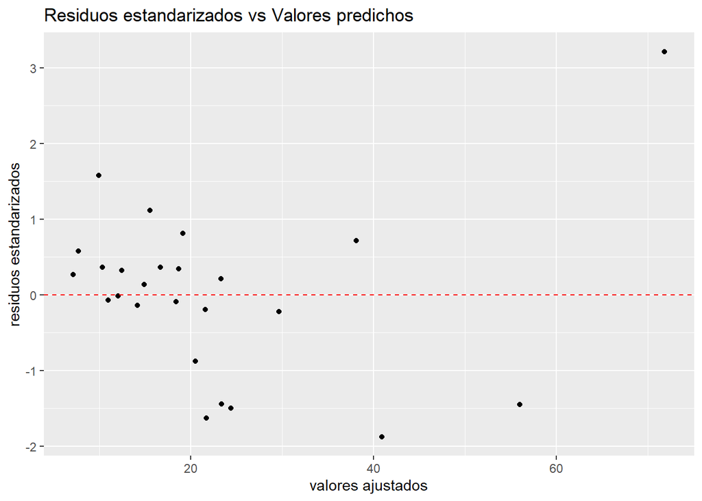

```r
ggplot(data = Tiempos2, aes(x = fitted(modelo2), y = rstandard(modelo2))) +
  geom_point() +
  geom_hline(yintercept = 0, linetype = "dashed", color = "red") +
  labs(x = "valores ajustados", y = "residuos estandarizados",
       title = "Residuos estandarizados vs Valores predichos")
```

## 14.2 Residuos vs. cada variable regresora

Estos gráficos sirven para detectar la existencia de una relación curvilínea entre los residuos y cada variable regresora. Esto indicaría que debiera incluirse un término $X_i^2$ o $ln(X_i)$ o alguna otra transformación.

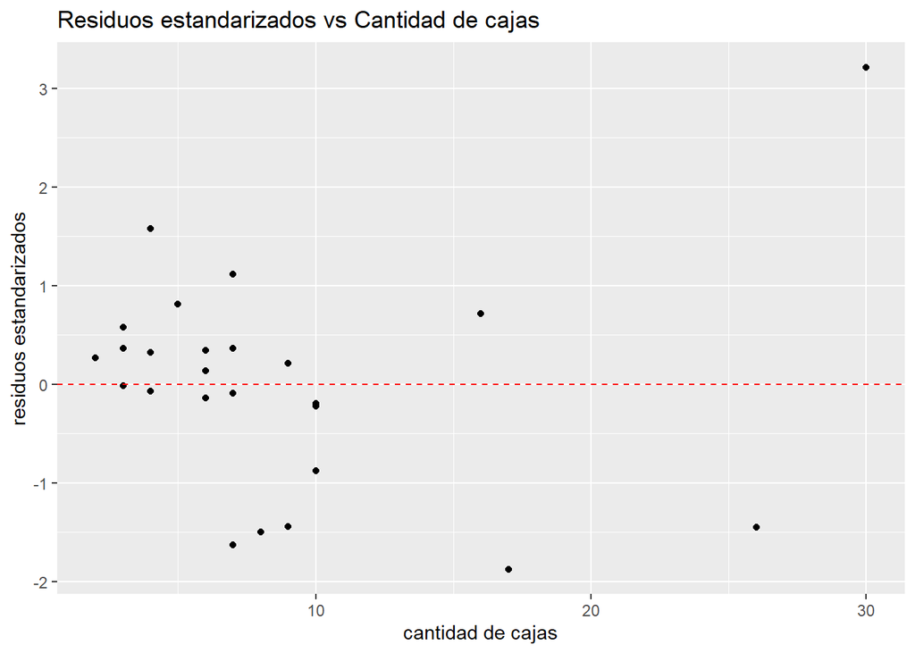

```r
ggplot(data = Tiempos2, aes(x = cajas, y = rstandard(modelo2))) +
  geom_point() +
  geom_hline(yintercept = 0, linetype = "dashed", color = "red") +
  labs(x = "cantidad de cajas", y = "residuos estandarizados",
       title = "Residuos estandarizados vs Cantidad de cajas")
```

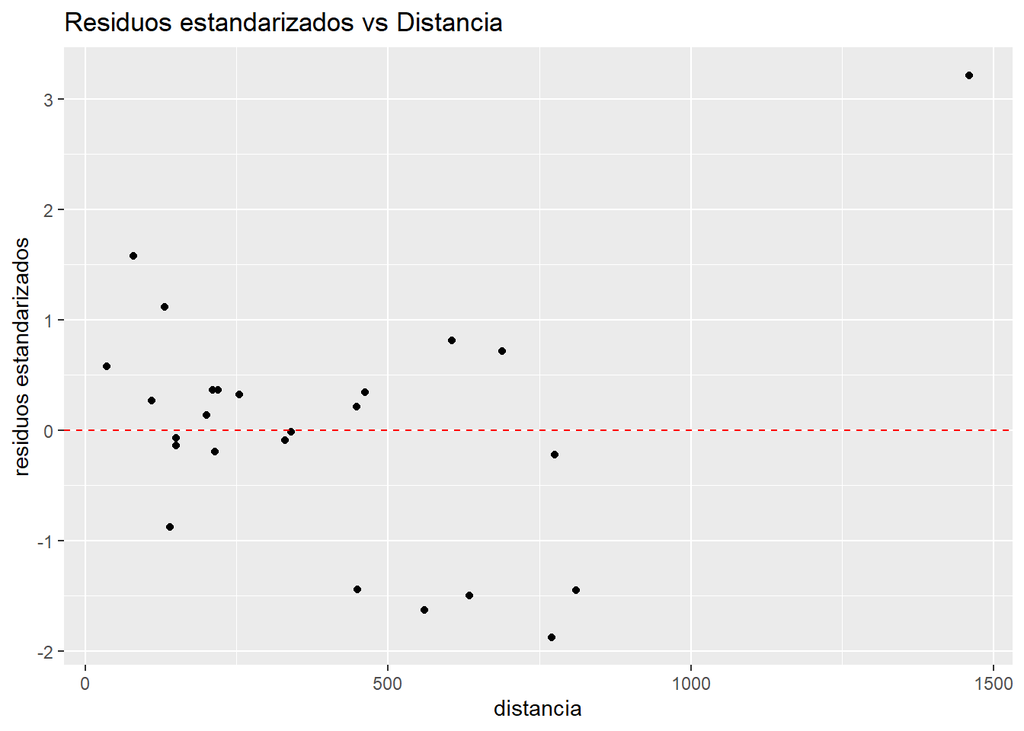

```r
ggplot(data = Tiempos2, aes(x = distancia, y = rstandard(modelo2))) +
  geom_point() +
  geom_hline(yintercept = 0, linetype = "dashed", color = "red") +
  labs(x = "distancia", y = "residuos estandarizados",
       title = "Residuos estandarizados vs Distancia")
```

## 14.3 Normalidad de los residuos

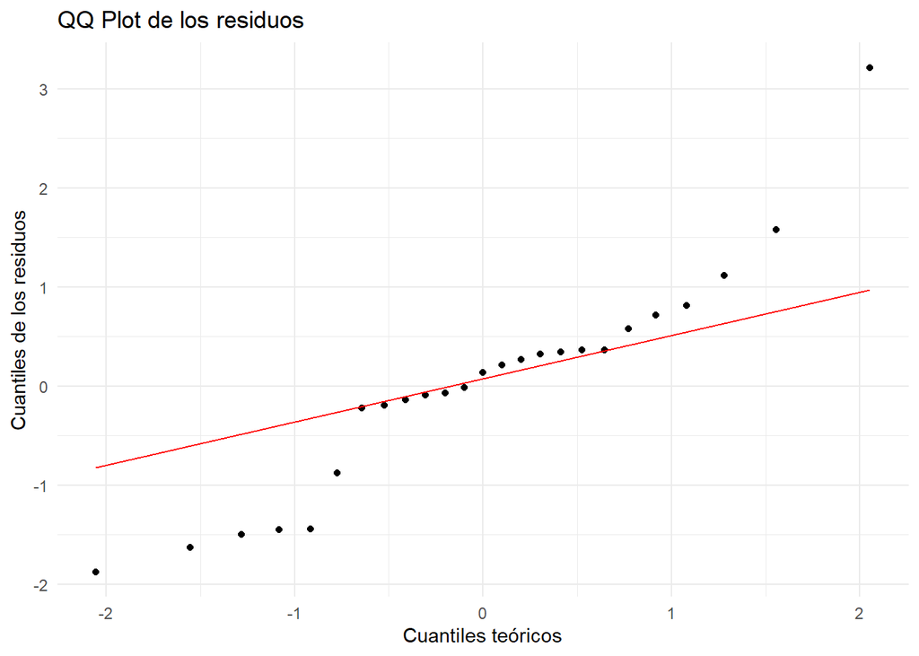

```r
residuos.df=data.frame(resid=rstandard(modelo2))
ggplot(data = residuos.df, aes(sample = rstandard(modelo2))) +
  stat_qq() +
  stat_qq_line(color = "red") +
  labs(title = "QQ Plot de los residuos",
       x = "Cuantiles teóricos", y = "Cuantiles de los residuos") +
  theme_minimal()
```

## 14.4 Análisis de puntos influyentes

## 14.5 Outliers

```r
sort(rstandard(modelo2))
```

```
##          20           1          24          22          23          21
## -1.87354643 -1.62767993 -1.49605875 -1.44999541 -1.44368977 -0.87784258
##          16          12           5           6          25           3
## -0.22270023 -0.19325733 -0.14176094 -0.09080847 -0.06750861 -0.01609165
##          17          15           7          13          14           2
##  0.13803929  0.21029137  0.27042496  0.32517935  0.34113547  0.36484267
##           8          19          11          10          18           4
##  0.36672118  0.57876634  0.71807970  0.81325432  1.11295196  1.57972040
##           9
##  3.21376278
```

### 14.5.1 Leverage

- Encuentro el leverage de cada observación

```r
leverage <- hatvalues(modelo)
leverage
```

```
##          1          2          3          4          5          6          7
## 0.11992977 0.10097319 0.10024969 0.10128434 0.16642759 0.08066357 0.07620000
##          8          9         10         11         12         13         14
## 0.06254612 0.06537738 0.11367920 0.07741039 0.06437975 0.04290146 0.09998709
##         15         16         17         18         19         20         21
## 0.04661503 0.04687996 0.08033747 0.11083391 0.20438000 0.13894064 0.14675966
##         22         23         24
## 0.18537865 0.21115081 0.55671434
```

- Defino el umbral

```r
p<-3
n=nrow(Tiempos2)
leverage_umbral<- 2 * p / n
```

- Encuentro las observaciones que superan el umbral

```r
leverage[leverage>leverage_umbral]
```

```
##        24
## 0.5567143
```

## 14.6 Distancia de Cook

- Encuentro las distancia de Cook de cada observación

```r
cooks <- cooks.distance(modelo)
```

- Defino el umbral

```r
p <- length(coef(modelo))
n=nrow(Tiempos2)
cooks_umbral <- qf(0.5,p,n-p)
```

- Encuentro las observaciones que superan el umbral

```r
cooks[cooks>cooks_umbral]
```

```
## named numeric(0)
```

- $\textit{Observación:}$ Las observaciones $9$ y $24$ son las que presentan residuos altos y alto leverage, respectivamente. Sin embargo, no presentan una distancia de Cook detectable como punto influeyente. Es de buena práctica estudiar el modelo sin estas observaciones para analizar los cambios que se pudieran producir.

# 15 Multicolinealidad

## 15.1 ¿Qué es la multicolinealidad?

La multicolinealidad ocurre cuando existe correlación entre dos o más variables regresoras.

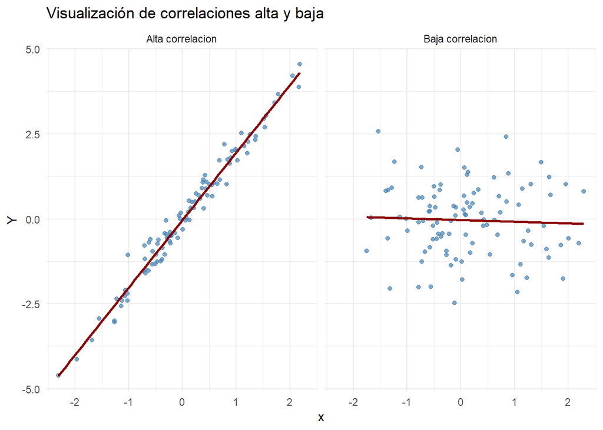

## 15.2 Causas de la multicolinealidad

- **Relaciones lógicas o matemáticas entre variables**  
  Variables que están construidas a partir de otras.  
  *Ejemplo:* población total y población urbana.
- **Variables derivadas unas de otras**  
  Incluir tanto una variable como una versión transformada o combinada.  
  *Ejemplo:* incluir tanto peso como el índice de masa corporal (IMC).
- **Variables naturalmente correlacionadas por contexto**  
  Algunas variables tienden a moverse juntas por razones sociales o económicas.  
  *Ejemplo:* nivel educativo y salario.
- **Redundancia por variables similares**  
  Incluir indicadores que miden aspectos muy parecidos.  
  *Ejemplo:* gasto mensual y gasto anual.
- **Tamaño de muestra pequeño**  
  Con pocos datos, las correlaciones entre variables explicativas se amplifican, generando efectos de colinealidad incluso con relaciones moderadas.

## 15.3 Problemas que causa la multicolinealidad

- Los estimadores de los coeficientes pueden cambiar drásticamente con pequeños cambios en los datos.
- Cuando se incluyen covariables altamente correlacionadas en un modelo, los errores estándar de los coeficientes estimados tienden a aumentar de manera artificial. A este fenómeno se lo conoce como inflación de la varianza de los estimadores.
- Los coeficientes pueden no resultar estadísticamente significativos, incluso cuando existe una relación real entre la variable dependiente y las variables explicativas.

## 15.4 Medida de diagnóstico de multicolinealidad

- Un método para detectar colinealidad entre las variables regresoras es el *Factor de Infalción de la Varianza* (VIF por sus siglas en inglés).
- Este factor se calcula para cada variable regresora.
- El VIF para la k-ésima variable regresora se define:

$$\mathrm{VIF}_k=\dfrac{1}{1-R_k^2}$$
con $k=1,\ldots,p-1$ y $R_k^2$ es el coeficiente de determinación múltiple cuando $X_k$ es regresado en las $p- 2$ restantes covariables $X$ en el modelo.

- $\mathrm{VIF}_k=1$ cuando $R_k^2=0$ : la covariable $X_k$ no está correlacionada con las demás.
- Si $R_k^2>0$, entonces $\mathrm{VIF}_k>1$ : hay algún grado de colinealidad.
- Si $R_k^2 \approx 1$, el $\mathrm{VIF}_k$ puede ser muy grande, indicando alta colinealidad.
- $\mathrm{VIF} > \mathbf{10} \rightarrow$ indicio fuerte de multicolinealidad.
- $\mathbf{5}<\mathrm{VIF} < \mathbf{10}$ indicio de moderada multicolinealidad.
- Otro criterio: si el promedio de los VIF es significativamente mayor a 1, también sugiere problemas de colinealidad.

## 15.5 Ejemplo

A continuación se muestra un ejemplo comparando dos modelos de regresión:

- Uno **sin multicolinealidad**, con tres variables independientes no correlacionadas.
- Otro **con multicolinealidad**, donde una variable es casi una copia de otra.

```r
set.seed(123)

# N° de observaciones
n <- 100

# Modelo sin multicolinealidad
x1 <- rnorm(n)
x2 <- rnorm(n)
x3 <- rnorm(n)
y1 <- 3 + 2 * x1 + 1.5 * x2 + 1 * x3 + rnorm(n)

datos1 <- data.frame(y = y1, x1 = x1, x2 = x2, x3 = x3)


# Modelo con multicolinealidad (x3 ≈ x1)
x3c <- x1 + rnorm(n, 0, 0.05)  # Alta correlación con x1
y2 <- 3 + 2 * x1 + 1.5 * x2 + 1 * x3c + rnorm(n)

y2 <- 3 + 2 * x1 + 1.5 * x2 + 1 * x3c + rnorm(n)

datos2 <- data.frame(y = y2, x1 = x1, x2 = x2, x3 = x3c)
```

## 15.6 Modelo sin multicolinealidad

- Salida del summary

```r
modelo_sin_col <- lm(y ~ x1 + x2 + x3, data = datos1)
summary(modelo_sin_col)
```

```
##
## Call:
## lm(formula = y ~ x1 + x2 + x3, data = datos1)
##
## Residuals:
##      Min       1Q   Median       3Q      Max
## -2.49138 -0.65392  0.05664  0.67033  2.53210
##
## Coefficients:
##             Estimate Std. Error t value Pr(>|t|)
## (Intercept)   2.9807     0.1073  27.768  < 2e-16 ***
## x1            1.9445     0.1169  16.638  < 2e-16 ***
## x2            1.5462     0.1095  14.126  < 2e-16 ***
## x3            0.9426     0.1122   8.399 4.04e-13 ***
## ---
## Signif. codes:  0 '***' 0.001 '**' 0.01 '*' 0.05 '.' 0.1 ' ' 1
##
## Residual standard error: 1.052 on 96 degrees of freedom
## Multiple R-squared:  0.8392, Adjusted R-squared:  0.8342
## F-statistic:   167 on 3 and 96 DF,  p-value: < 2.2e-16
```

- Residuos vs. valores ajustados

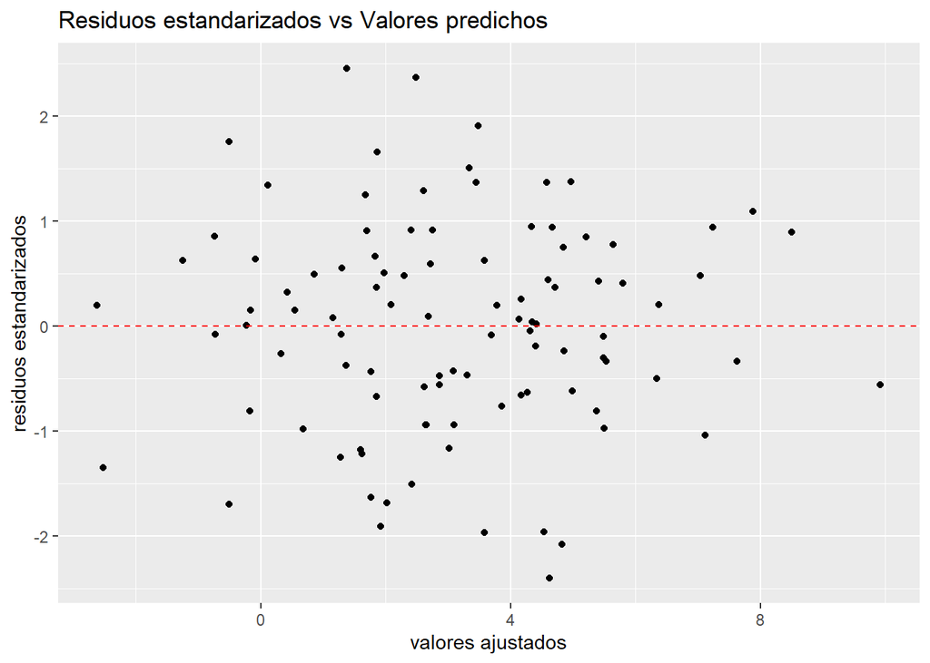

```r
ggplot(data = datos1 , aes(x = fitted(modelo_sin_col), y = rstandard(modelo_sin_col))) +
  geom_point() +
  geom_hline(yintercept = 0, linetype = "dashed", color = "red") +
  labs(x = "valores ajustados", y = "residuos estandarizados",
       title = "Residuos estandarizados vs Valores predichos")
```

- Residuos vs. cada variable regresora

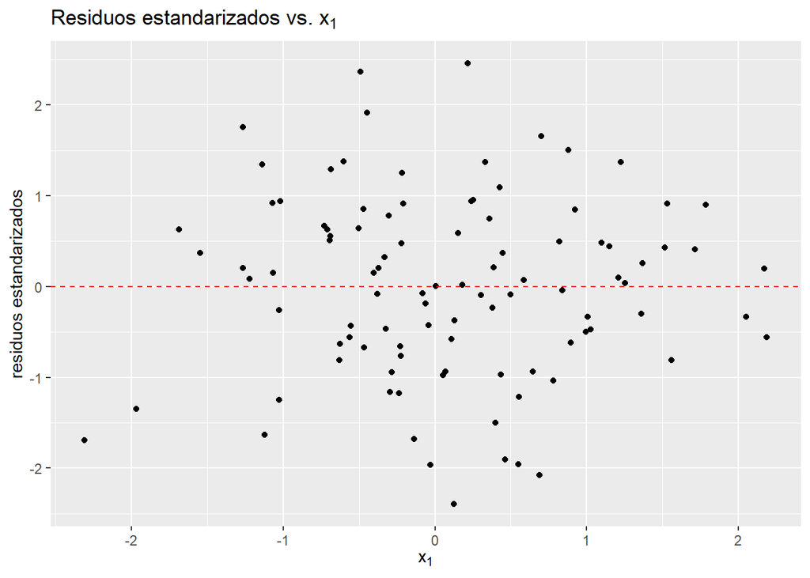

```r
ggplot(data = datos1 , aes(x = x1, y = rstandard(modelo_sin_col))) +
  geom_point() +
  geom_hline(yintercept = 0, linetype = "dashed", color = "red") +
  labs(x = expression(x[1]), y = "residuos estandarizados",
       title = expression(paste("Residuos estandarizados vs. ", x[1])))
```

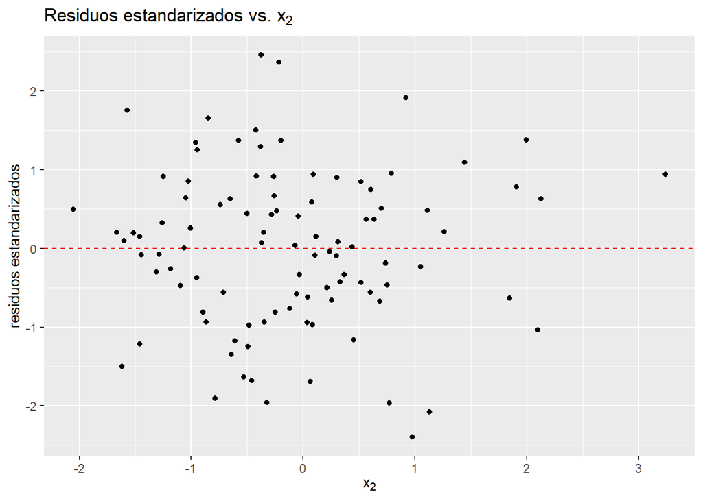

```r
ggplot(data = datos1 , aes(x = x2, y = rstandard(modelo_sin_col))) +
  geom_point() +
  geom_hline(yintercept = 0, linetype = "dashed", color = "red") +
  labs(x = expression(x[2]), y = "residuos estandarizados",
       title = expression(paste("Residuos estandarizados vs. ", x[2])))
```

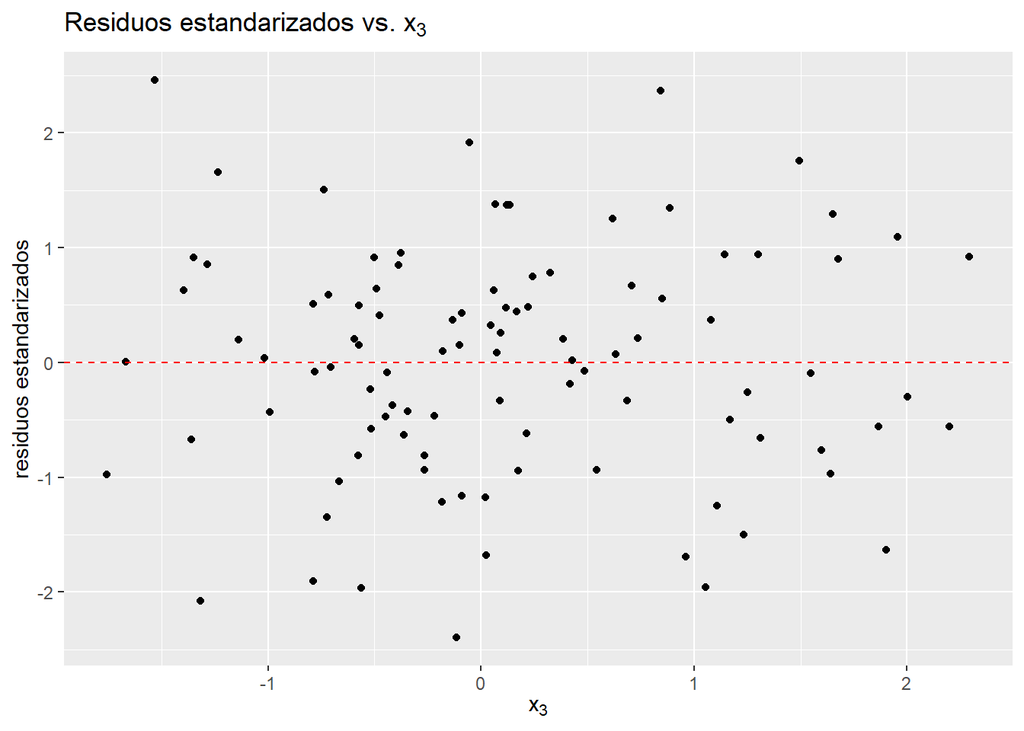

```r
ggplot(data = datos1 , aes(x = x3, y = rstandard(modelo_sin_col))) +
  geom_point() +
  geom_hline(yintercept = 0, linetype = "dashed", color = "red") +
  labs(x = expression(x[3]), y = "residuos estandarizados",
       title = expression(paste("Residuos estandarizados vs. ", x[3])))
```

## 15.7 Normalidad de los residuos

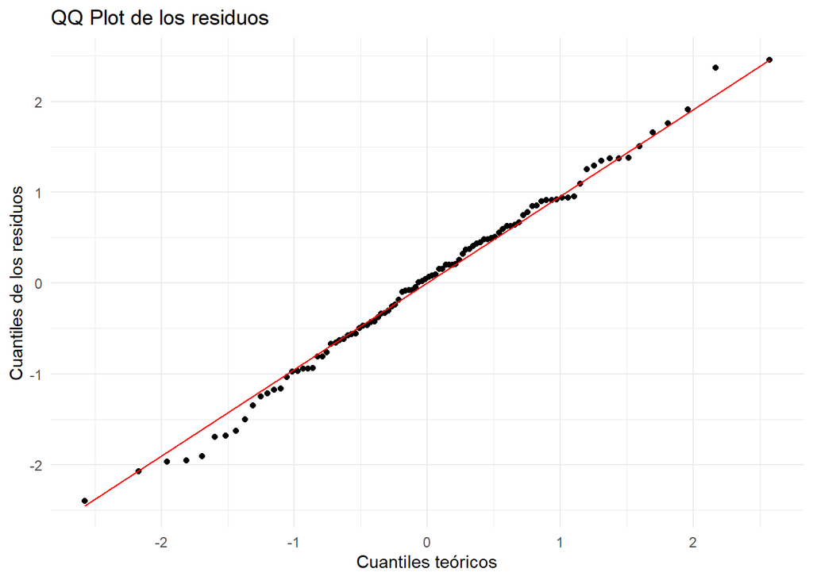

```r
residuos.df=data.frame(resid=rstandard(modelo_sin_col))
ggplot(data = residuos.df, aes(sample = rstandard(modelo_sin_col))) +
  stat_qq() +
  stat_qq_line(color = "red") +
  labs(title = "QQ Plot de los residuos",
       x = "Cuantiles teóricos", y = "Cuantiles de los residuos") +
  theme_minimal()
```

## 15.8 Modelo con multicolinealidad

- Summary

```r
modelo_con_col <- lm(y ~ x1 + x2 + x3, data = datos2)
summary(modelo_con_col)
```

```
##
## Call:
## lm(formula = y ~ x1 + x2 + x3, data = datos2)
##
## Residuals:
##      Min       1Q   Median       3Q      Max
## -2.43303 -0.74973  0.04546  0.70439  2.40904
##
## Coefficients:
##             Estimate Std. Error t value Pr(>|t|)
## (Intercept)   2.8625     0.1058  27.047   <2e-16 ***
## x1            2.0176     2.1563   0.936    0.352
## x2            1.5811     0.1094  14.452   <2e-16 ***
## x3            0.9474     2.1768   0.435    0.664
## ---
## Signif. codes:  0 '***' 0.001 '**' 0.01 '*' 0.05 '.' 0.1 ' ' 1
##
## Residual standard error: 1.04 on 96 degrees of freedom
## Multiple R-squared:  0.8974, Adjusted R-squared:  0.8942
## F-statistic:   280 on 3 and 96 DF,  p-value: < 2.2e-16
```

- Residuos vs. valores ajustados

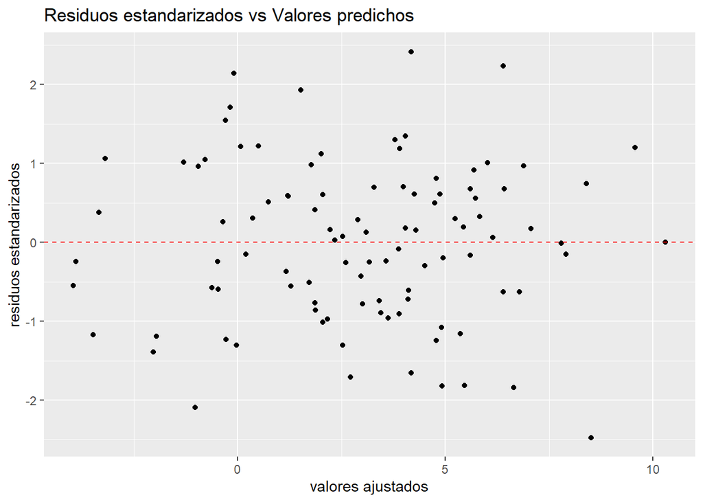

```r
ggplot(data = datos2, aes(x = fitted(modelo_con_col), y = rstandard(modelo_con_col))) +
  geom_point() +
  geom_hline(yintercept = 0, linetype = "dashed", color = "red") +
  labs(x = "valores ajustados", y = "residuos estandarizados",
       title = "Residuos estandarizados vs Valores predichos")
```

- Residuos vs. cada variable regresora

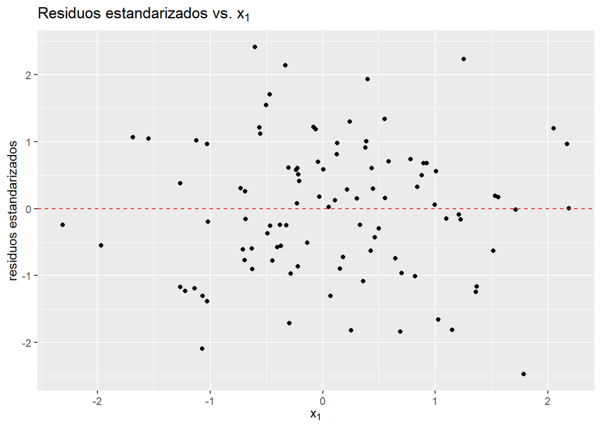

```r
ggplot(data = datos2, aes(x = x1, y = rstandard(modelo_con_col))) +
  geom_point() +
  geom_hline(yintercept = 0, linetype = "dashed", color = "red") +
  labs(x = expression(x[1]), y = "residuos estandarizados",
       title = expression(paste("Residuos estandarizados vs. ", x[1])))
```

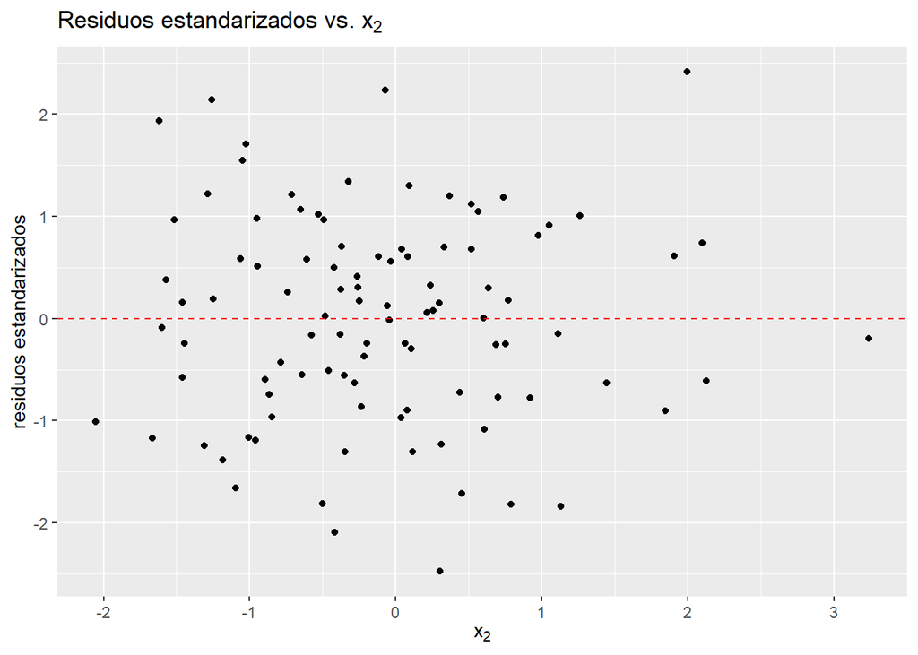

```r
ggplot(data = datos2, aes(x = x2, y = rstandard(modelo_con_col))) +
  geom_point() +
  geom_hline(yintercept = 0, linetype = "dashed", color = "red") +
  labs(x = expression(x[2]), y = "residuos estandarizados",
       title = expression(paste("Residuos estandarizados vs. ", x[2])))
```

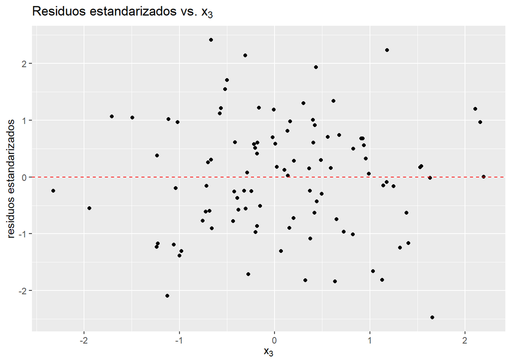

```r
ggplot(data = datos2, aes(x = x3, y = rstandard(modelo_con_col))) +
  geom_point() +
  geom_hline(yintercept = 0, linetype = "dashed", color = "red") +
  labs(x = expression(x[3]), y = "residuos estandarizados",
       title = expression(paste("Residuos estandarizados vs. ", x[3])))
```